# tarea 2 german

equipo CAL: Carlos Petricioli, Amanda Balderas, Liliana Millán

16 de noviembre de 2014

# Introducción

Archivo german 1000 observaciones, obtenido del repositorio de Adolfo de Unanue Tiscareño https://github.com/nanounanue/itam-dm/tree/master/data/german.

Este set de datos clasifica a clientes como buenos o malos riesgos para otorgarles créditos bancarios.

## Variables

El set contiene 20 atributos en el siguiente orden:

| campo | atributo | valores | tipo |
| --- | --- | --- | --- |
| 1 | estatus de su cuenta actual | A11,A12,A13,A14 | categrórica |
| 2 | duración en meses | reales positivos | numérica |
| 3 | historia creditica | A30,A31,A32,A33,A34 | categórica |
| 4 | próposito | A40,A41,A42,A43,A44,A45,A46,A47,A48,A49,A410 | categórica |
| 5 | monto crediticio | reales positivos | numérica |
| 6 | cuenta de ahorro/bonos | A61,A62,A63,A64,A65 | categórica |
| 7 | empleo actual desde | A71,A72,A73,A74,A75 | categórica |
| 8 | porcentaje de capacidad de pago | reales positivos | numérica |
| 9 | estado civil y género | A91,A92,A93,A94,A95 | categórica |
| 10 | otros acreedores | A101,A102,A103 | categórica |
| 11 | vivienda actual desde | reales positivos | numérica |
| 12 | propiedad | A121,A122,A123,A124 | categórica |
| 13 | edad en años | reales positivos | numérica |
| 14 | otros planes de pago | A141,A142,A143 | categórica |
| 15 | tipo de vivienda | A151,A152,A153 | categórica |
| 16 | número de créditos que tiene en este banco | reales positivos | numérica |
| 17 | trabajo | A171,A172,A173,A174,A175 | categórica |
| 18 | número de dependientes económicos | reales positivos | numérica |
| 19 | teléfono | A191,A192 | categórica |
| 20 | trabajador extranjero | A201,A202 | categórica |
| 21 | crédito bueno/crédito malo | 1,2 | categórica |

# Estructura General

```r
ds
```

```
## Source: local data frame [1,000 x 21]
##
##     V1 V2  V3  V4   V5  V6  V7 V8  V9  V10 V11  V12 V13  V14  V15 V16  V17
## 1  A11  6 A34 A43 1169 A65 A75  4 A93 A101   4 A121  67 A143 A152   2 A173
## 2  A12 48 A32 A43 5951 A61 A73  2 A92 A101   2 A121  22 A143 A152   1 A173
## 3  A14 12 A34 A46 2096 A61 A74  2 A93 A101   3 A121  49 A143 A152   1 A172
## 4  A11 42 A32 A42 7882 A61 A74  2 A93 A103   4 A122  45 A143 A153   1 A173
## 5  A11 24 A33 A40 4870 A61 A73  3 A93 A101   4 A124  53 A143 A153   2 A173
## 6  A14 36 A32 A46 9055 A65 A73  2 A93 A101   4 A124  35 A143 A153   1 A172
## 7  A14 24 A32 A42 2835 A63 A75  3 A93 A101   4 A122  53 A143 A152   1 A173
## 8  A12 36 A32 A41 6948 A61 A73  2 A93 A101   2 A123  35 A143 A151   1 A174
## 9  A14 12 A32 A43 3059 A64 A74  2 A91 A101   4 A121  61 A143 A152   1 A172
## 10 A12 30 A34 A40 5234 A61 A71  4 A94 A101   2 A123  28 A143 A152   2 A174
## .. ... .. ... ...  ... ... ... .. ...  ... ...  ... ...  ...  ... ...  ...
## Variables not shown: V18 (int), V19 (chr), V20 (chr), V21 (int)
```

## Tamaño

```r
dim(ds)
```

```
## [1] 1000   21
```

## Columnas

Agregaremos los nombres a las columnas

```r
names(ds) <- german.colnames()

names(ds)
```

```
##  [1] "Status of existing checking account"
##  [2] "Duration in month"
##  [3] "Credit history"
##  [4] "Purpose"
##  [5] "Credit amount"
##  [6] "Savings account/bonds"
##  [7] "Present employment since"
##  [8] "Installment rate in percentage of disposable income"
##  [9] "Personal status and sex"
## [10] "Other debtors / guarantors"
## [11] "Present residence since"
## [12] "Property"
## [13] "Age in years"
## [14] "Other installment plans"
## [15] "Housing"
## [16] "Number of existing credits at this bank"
## [17] "Job"
## [18] "Number of people being liable to provide maintenance for"
## [19] "Telephone"
## [20] "foreign worker"
## [21] "Good.Loan"
```

## Estructura

Verificaremos si los contenidos tienen sentido con respecto a lo que debería almacenar cada variable, para ello decodificamos cada valor categórico por su descripción.

Todas las variables coinciden en sus tipos.

```
## Classes 'tbl_df', 'tbl' and 'data.frame':    1000 obs. of  21 variables:
##  $ Status of existing checking account                     : chr  "... < 0 DM" "0 <= ... < 200 DM" "no checking account" "... < 0 DM" ...
##  $ Duration in month                                       : int  6 48 12 42 24 36 24 36 12 30 ...
##  $ Credit history                                          : chr  "critical account/other credits existing (not at this bank)" "existing credits paid back duly till now" "critical account/other credits existing (not at this bank)" "existing credits paid back duly till now" ...
##  $ Purpose                                                 : chr  "radio/television" "radio/television" "education" "furniture/equipment" ...
##  $ Credit amount                                           : int  1169 5951 2096 7882 4870 9055 2835 6948 3059 5234 ...
##  $ Savings account/bonds                                   : chr  "unknown/ no savings account" "... < 100 DM" "... < 100 DM" "... < 100 DM" ...
##  $ Present employment since                                : chr  ".. >= 7 years" "1 <= ... < 4 years" "4 <= ... < 7 years" "4 <= ... < 7 years" ...
##  $ Installment rate in percentage of disposable income     : int  4 2 2 2 3 2 3 2 2 4 ...
##  $ Personal status and sex                                 : chr  "male : single" "female : divorced/separated/married" "male : single" "male : single" ...
##  $ Other debtors / guarantors                              : chr  "none" "none" "none" "guarantor" ...
##  $ Present residence since                                 : int  4 2 3 4 4 4 4 2 4 2 ...
##  $ Property                                                : chr  "real estate" "real estate" "real estate" "if not A121 : building society savings agreement/life insurance" ...
##  $ Age in years                                            : int  67 22 49 45 53 35 53 35 61 28 ...
##  $ Other installment plans                                 : chr  "none" "none" "none" "none" ...
##  $ Housing                                                 : chr  "own" "own" "own" "for free" ...
##  $ Number of existing credits at this bank                 : int  2 1 1 1 2 1 1 1 1 2 ...
##  $ Job                                                     : chr  "skilled employee / official" "skilled employee / official" "unskilled - resident" "skilled employee / official" ...
##  $ Number of people being liable to provide maintenance for: int  1 1 2 2 2 2 1 1 1 1 ...
##  $ Telephone                                               : chr  "yes, registered under the customers name" "none" "none" "none" ...
##  $ foreign worker                                          : chr  "yes" "yes" "yes" "yes" ...
##  $ Good.Loan                                               : Factor w/ 2 levels "BadLoan","GoodLoan": 2 1 2 2 1 2 2 2 2 1 ...
```

## Observaciones

```r
head(ds)
```

```
## Source: local data frame [6 x 21]
##
##   Status of existing checking account Duration in month
## 1                          ... < 0 DM                 6
## 2                   0 <= ... < 200 DM                48
## 3                 no checking account                12
## 4                          ... < 0 DM                42
## 5                          ... < 0 DM                24
## 6                 no checking account                36
## Variables not shown: Credit history (chr), Purpose (chr), Credit amount
##   (int), Savings account/bonds (chr), Present employment since (chr),
##   Installment rate in percentage of disposable income (int), Personal
##   status and sex (chr), Other debtors / guarantors (chr), Present
##   residence since (int), Property (chr), Age in years (int), Other
##   installment plans (chr), Housing (chr), Number of existing credits at
##   this bank (int), Job (chr), Number of people being liable to provide
##   maintenance for (int), Telephone (chr), foreign worker (chr), Good.Loan
##   (fctr)
```

```r
tail(ds)
```

```
## Source: local data frame [6 x 21]
##
##      Status of existing checking account Duration in month
## 995                  no checking account                12
## 996                  no checking account                12
## 997                           ... < 0 DM                30
## 998                  no checking account                12
## 999                           ... < 0 DM                45
## 1000                   0 <= ... < 200 DM                45
## Variables not shown: Credit history (chr), Purpose (chr), Credit amount
##   (int), Savings account/bonds (chr), Present employment since (chr),
##   Installment rate in percentage of disposable income (int), Personal
##   status and sex (chr), Other debtors / guarantors (chr), Present
##   residence since (int), Property (chr), Age in years (int), Other
##   installment plans (chr), Housing (chr), Number of existing credits at
##   this bank (int), Job (chr), Number of people being liable to provide
##   maintenance for (int), Telephone (chr), foreign worker (chr), Good.Loan
##   (fctr)
```

```r
ds[sample(1:dim(ds)[1],6),]
```

```
## Source: local data frame [6 x 21]
##
##     Status of existing checking account Duration in month
## 609                 no checking account                18
## 132                          ... < 0 DM                36
## 205                 no checking account                12
## 883                   0 <= ... < 200 DM                30
## 436                   0 <= ... < 200 DM                12
## 743                 no checking account                21
## Variables not shown: Credit history (chr), Purpose (chr), Credit amount
##   (int), Savings account/bonds (chr), Present employment since (chr),
##   Installment rate in percentage of disposable income (int), Personal
##   status and sex (chr), Other debtors / guarantors (chr), Present
##   residence since (int), Property (chr), Age in years (int), Other
##   installment plans (chr), Housing (chr), Number of existing credits at
##   this bank (int), Job (chr), Number of people being liable to provide
##   maintenance for (int), Telephone (chr), foreign worker (chr), Good.Loan
##   (fctr)
```

# Sumario Estadístico

```r
summary(ds)
```

```
##  Status of existing checking account Duration in month Credit history
##  Length:1000                         Min.   : 4.0      Length:1000
##  Class :character                    1st Qu.:12.0      Class :character
##  Mode  :character                    Median :18.0      Mode  :character
##                                      Mean   :20.9
##                                      3rd Qu.:24.0
##                                      Max.   :72.0
##    Purpose          Credit amount   Savings account/bonds
##  Length:1000        Min.   :  250   Length:1000
##  Class :character   1st Qu.: 1366   Class :character
##  Mode  :character   Median : 2320   Mode  :character
##                     Mean   : 3271
##                     3rd Qu.: 3972
##                     Max.   :18424
##  Present employment since
##  Length:1000
##  Class :character
##  Mode  :character
##
##
##
##  Installment rate in percentage of disposable income
##  Min.   :1.00
##  1st Qu.:2.00
##  Median :3.00
##  Mean   :2.97
##  3rd Qu.:4.00
##  Max.   :4.00
##  Personal status and sex Other debtors / guarantors
##  Length:1000             Length:1000
##  Class :character        Class :character
##  Mode  :character        Mode  :character
##
##
##
##  Present residence since   Property          Age in years
##  Min.   :1.00            Length:1000        Min.   :19.0
##  1st Qu.:2.00            Class :character   1st Qu.:27.0
##  Median :3.00            Mode  :character   Median :33.0
##  Mean   :2.85                               Mean   :35.5
```

[output cut: 15 more lines]

```
##  Max.   :4.00
##  Number of people being liable to provide maintenance for
##  Min.   :1.00
##  1st Qu.:1.00
##  Median :1.00
##  Mean   :1.16
##  3rd Qu.:1.00
##  Max.   :2.00
##   Telephone         foreign worker        Good.Loan
##  Length:1000        Length:1000        BadLoan :300
##  Class :character   Class :character   GoodLoan:700
##  Mode  :character   Mode  :character
##
##
##
```

# Limpieza de metadatos

Quitando espacios, diagonales y mayúsculas a minúsculas.

```
##  [1] "status.of.existing.checking.account"
##  [2] "duration.in.month"
##  [3] "credit.history"
##  [4] "purpose"
##  [5] "credit.amount"
##  [6] "savings.account.bonds"
##  [7] "present.employment.since"
##  [8] "installment.rate.in.percentage.of.disposable.income"
##  [9] "personal.status.and.sex"
## [10] "other.debtors...guarantors"
## [11] "present.residence.since"
## [12] "property"
## [13] "age.in.years"
## [14] "other.installment.plans"
## [15] "housing"
## [16] "number.of.existing.credits.at.this.bank"
## [17] "job"
## [18] "number.of.people.being.liable.to.provide.maintenance.for"
## [19] "telephone"
## [20] "foreign.worker"
## [21] "good.loan"
```

# Ajuste de formatos

Las clases de las variables son

```r
sapply(ds, class)
```

```
##                      status.of.existing.checking.account
##                                              "character"
##                                        duration.in.month
##                                                "integer"
##                                           credit.history
##                                              "character"
##                                                  purpose
##                                              "character"
##                                            credit.amount
##                                                "integer"
##                                    savings.account.bonds
##                                              "character"
##                                 present.employment.since
##                                              "character"
##      installment.rate.in.percentage.of.disposable.income
##                                                "integer"
##                                  personal.status.and.sex
##                                              "character"
##                               other.debtors...guarantors
##                                              "character"
##                                  present.residence.since
##                                                "integer"
##                                                 property
##                                              "character"
##                                             age.in.years
##                                                "integer"
##                                  other.installment.plans
##                                              "character"
##                                                  housing
##                                              "character"
##                  number.of.existing.credits.at.this.bank
##                                                "integer"
##                                                      job
##                                              "character"
## number.of.people.being.liable.to.provide.maintenance.for
##                                                "integer"
##                                                telephone
##                                              "character"
##                                           foreign.worker
##                                              "character"
##                                                good.loan
##                                                 "factor"
```

Cambiaremos los tipos de character a factor.

```
##                      status.of.existing.checking.account
##                                                 "factor"
##                                        duration.in.month
##                                                "integer"
##                                           credit.history
##                                                 "factor"
##                                                  purpose
##                                                 "factor"
##                                            credit.amount
##                                                "integer"
##                                    savings.account.bonds
##                                                 "factor"
##                                 present.employment.since
##                                                 "factor"
##      installment.rate.in.percentage.of.disposable.income
##                                                "integer"
##                                  personal.status.and.sex
##                                                 "factor"
##                               other.debtors...guarantors
##                                                 "factor"
##                                  present.residence.since
##                                                "integer"
##                                                 property
##                                                 "factor"
##                                             age.in.years
##                                                "integer"
##                                  other.installment.plans
##                                                 "factor"
##                                                  housing
##                                                 "factor"
##                  number.of.existing.credits.at.this.bank
##                                                "integer"
##                                                      job
##                                                 "factor"
## number.of.people.being.liable.to.provide.maintenance.for
##                                                "integer"
##                                                telephone
##                                                 "factor"
##                                           foreign.worker
##                                                 "factor"
##                                                good.loan
##                                                 "factor"
```

En este set de datos no hay fechas.

# Transformación de variables

En el set de datos de german no se realizó ninguna transformación de variable.

Se ocupó como id el rowname.

En el set de datos de german no hay una variable risk ni costo asociada a la variable target.

# Recodificación

No se requirió recodificar las variables categóricas ya que tienen a lo más 10 niveles (Purpose) y no hay variables de fechas.

```r
str(ds)
```

```
## Classes 'tbl_df', 'tbl' and 'data.frame':    1000 obs. of  21 variables:
##  $ status.of.existing.checking.account                     : Factor w/ 4 levels "... < 0 DM","... >= 200 DM / salary assignments for at least 1 year",..: 1 3 4 1 1 4 4 3 4 3 ...
##  $ duration.in.month                                       : int  6 48 12 42 24 36 24 36 12 30 ...
##  $ credit.history                                          : Factor w/ 5 levels "all credits at this bank paid back duly",..: 2 4 2 4 3 4 4 4 4 2 ...
##  $ purpose                                                 : Factor w/ 10 levels "business","car (new)",..: 8 8 5 6 2 5 6 3 8 2 ...
##  $ credit.amount                                           : int  1169 5951 2096 7882 4870 9055 2835 6948 3059 5234 ...
##  $ savings.account.bonds                                   : Factor w/ 5 levels ".. >= 1000 DM",..: 5 2 2 2 2 5 4 2 1 2 ...
##  $ present.employment.since                                : Factor w/ 5 levels ".. >= 7 years",..: 1 3 4 4 3 3 1 3 4 5 ...
##  $ installment.rate.in.percentage.of.disposable.income     : int  4 2 2 2 3 2 3 2 2 4 ...
##  $ personal.status.and.sex                                 : Factor w/ 4 levels "female : divorced/separated/married",..: 4 1 4 4 4 4 4 4 2 3 ...
##  $ other.debtors...guarantors                              : Factor w/ 3 levels "co-applicant",..: 3 3 3 2 3 3 3 3 3 3 ...
##  $ present.residence.since                                 : int  4 2 3 4 4 4 4 2 4 2 ...
##  $ property                                                : Factor w/ 4 levels "if not A121 : building society savings agreement/life insurance",..: 3 3 3 1 4 4 1 2 3 2 ...
##  $ age.in.years                                            : int  67 22 49 45 53 35 53 35 61 28 ...
##  $ other.installment.plans                                 : Factor w/ 3 levels "bank","none",..: 2 2 2 2 2 2 2 2 2 2 ...
##  $ housing                                                 : Factor w/ 3 levels "for free","own",..: 2 2 2 1 1 1 2 3 2 2 ...
##  $ number.of.existing.credits.at.this.bank                 : int  2 1 1 1 2 1 1 1 1 2 ...
##  $ job                                                     : Factor w/ 4 levels "management/ self-employed/highly qualified employee/ officer",..: 2 2 4 2 2 4 2 1 4 1 ...
##  $ number.of.people.being.liable.to.provide.maintenance.for: int  1 1 2 2 2 2 1 1 1 1 ...
##  $ telephone                                               : Factor w/ 2 levels "none","yes, registered under the customers name": 2 1 1 1 1 2 1 2 1 1 ...
##  $ foreign.worker                                          : Factor w/ 2 levels "no","yes": 2 2 2 2 2 2 2 2 2 2 ...
##  $ good.loan                                               : Factor w/ 2 levels "BadLoan","GoodLoan": 2 1 2 2 1 2 2 2 2 1 ...
```

# Variables a ignorar

Ignoraremos las última columna (Good.Loan) que es la variable que queremos inferir.

### IDs y variables de salida

### Constantes y valores únicos por observación

En el set de datos de german no se encontraron muchos niveles, el de mayor nivel tiene 10 niveles diferentes (Purpose), tampoco se encontraron variables que sean constantes.

```
## character(0)
```

### Faltantes

```r
# Las que sean puros NAs
ids.nas.count <- sapply(ds[vars], function(x) sum(is.na(x)))
ids.nas <- names(which(ids.nas.count == nrow(ds)))

vars.a.ignorar <- union(ids.nas, vars.a.ignorar)

# Las que tengan muchos NAs (un 70% o más)
ids.many.nas <- names(which(ids.nas.count >= 0.7*nrow(ds)))

vars.a.ignorar <- union(ids.many.nas, vars.a.ignorar)
```

### Variable de salida (`target`)

La varaible target ya es categórica.

```
## [1] "factor"
```

No hubo NA’s en las columna target.

```
## [1] 1000   21
```

```
## [1] 1000   21
```

Mostramos la distribución (esto nos indicará si el problema no está balanceado). Para el data set de german, hay un poco más del doble de casos con ‘Good.Loan’ que de casos con ‘Bad.Loan’

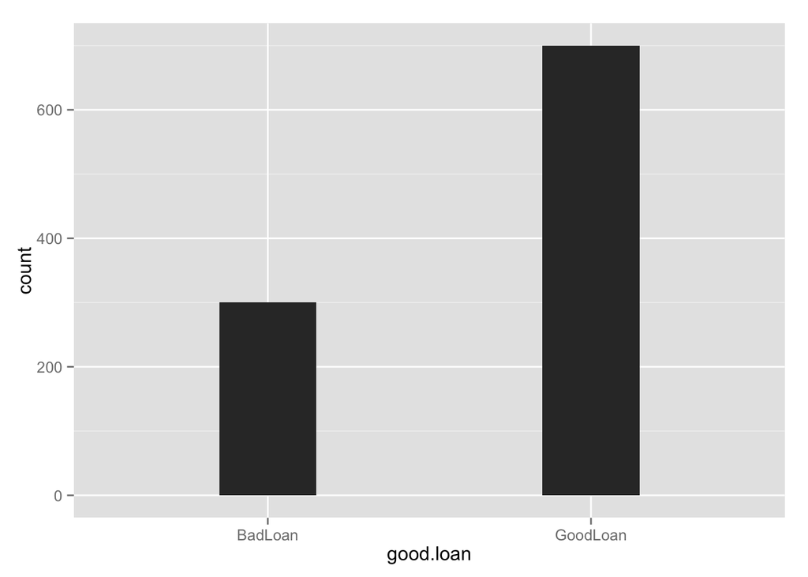

# Variables correlacionadas

```r
vars.cor <- cor(ds[which(sapply(ds, is.numeric))], use="complete.obs")
vars.cor[upper.tri(vars.cor, diag=TRUE)] <- NA

vars.cor <- vars.cor                                  %>%
            abs()                                     %>%
            data.frame()                              %>%
            mutate(var1=row.names(vars.cor))          %>%
            gather(var2, cor, -var1)                  %>%
            na.omit()


vars.cor <- vars.cor[order(-abs(vars.cor$cor)), ]

(muy.cor <- filter(vars.cor, cor > 0.95)) # Mostramos las que tengan más del 95% de correlación

# Habría que decidir si se remueven y cuales se remueven (var1 o var2)
vars.a.ignorar <- union(vars.a.ignorar, muy.cor$var2)
```

[output not shown]

No hubo columnas que tuvieran mas del 95% de correlacion entre ellas para las variables numéricas.

# Valores faltantes

En el set de datos german no hay valores faltantes en los datos numéricos (de acuerdo al summary)

```
##                                      status.of.existing.checking.account
##  ... < 0 DM                                            :274
##  ... >= 200 DM / salary assignments for at least 1 year: 63
##  0 <= ... < 200 DM                                     :269
##  no checking account                                   :394
##
##
##
##  duration.in.month
##  Min.   : 4.0
##  1st Qu.:12.0
##  Median :18.0
##  Mean   :20.9
##  3rd Qu.:24.0
##  Max.   :72.0
##
##                                                     credit.history
##  all credits at this bank paid back duly                   : 49
##  critical account/other credits existing (not at this bank):293
##  delay in paying off in the past                           : 88
##  existing credits paid back duly till now                  :530
##  no credits taken/all credits paid back duly               : 40
##
##
##                 purpose    credit.amount
##  radio/television   :280   Min.   :  250
##  car (new)          :234   1st Qu.: 1366
##  furniture/equipment:181   Median : 2320
##  car (used)         :103   Mean   : 3271
##  business           : 97   3rd Qu.: 3972
##  education          : 50   Max.   :18424
##  (Other)            : 55
##                  savings.account.bonds       present.employment.since
##  .. >= 1000 DM              : 48       .. >= 7 years     :253
##  ... < 100 DM               :603       ... < 1 year      :172
##  100 <= ... < 500 DM        :103       1 <= ... < 4 years:339
##  500 <= ... < 1000 DM       : 63       4 <= ... < 7 years:174
##  unknown/ no savings account:183       unemployed        : 62
##
##
```

[output cut: 65 more lines]

```
##  none                                    :596   no : 37
##  yes, registered under the customers name:404   yes:963
##
##
##
##
##
##     good.loan
##  BadLoan :300
##  GoodLoan:700
##
##
##
##
##
```

Para las variables categoricas tampoco hay faltantes :)

```
## $status.of.existing.checking.account
## [1] ... < 0 DM
## [2] 0 <= ... < 200 DM
## [3] no checking account
## [4] ... >= 200 DM / salary assignments for at least 1 year
## 4 Levels: ... < 0 DM ...
##
## $credit.history
## [1] critical account/other credits existing (not at this bank)
## [2] existing credits paid back duly till now
## [3] delay in paying off in the past
## [4] no credits taken/all credits paid back duly
## [5] all credits at this bank paid back duly
## 5 Levels: all credits at this bank paid back duly ...
##
## $purpose
##  [1] radio/television    education           furniture/equipment
##  [4] car (new)           car (used)          business
##  [7] domestic appliances repairs             others
## [10] retraining
## 10 Levels: business car (new) car (used) domestic appliances ... retraining
##
## $savings.account.bonds
## [1] unknown/ no savings account ... < 100 DM
## [3] 500 <= ... < 1000 DM        .. >= 1000 DM
## [5] 100 <= ... < 500 DM
## 5 Levels: .. >= 1000 DM ... < 100 DM ... unknown/ no savings account
##
## $present.employment.since
## [1] .. >= 7 years      1 <= ... < 4 years 4 <= ... < 7 years
## [4] unemployed         ... < 1 year
## 5 Levels: .. >= 7 years ... < 1 year ... unemployed
##
## $personal.status.and.sex
## [1] male : single                       female : divorced/separated/married
## [3] male : divorced/separated           male : married/widowed
## 4 Levels: female : divorced/separated/married ...
##
## $other.debtors...guarantors
## [1] none         guarantor    co-applicant
```

[output cut: 21 more lines]

```
## [4] unemployed/ unskilled - non-resident
## 4 Levels: management/ self-employed/highly qualified employee/ officer ...
##
## $telephone
## [1] yes, registered under the customers name
## [2] none
## Levels: none yes, registered under the customers name
##
## $foreign.worker
## [1] yes no
## Levels: no yes
##
## $good.loan
## [1] GoodLoan BadLoan
## Levels: BadLoan GoodLoan
```

# Normalizar niveles

Removemos espacios, puntuaciones, camelCase, etc. en los niveles de los factores supervivientes.

```r
ds[t] <- lapply(ds[t], function(x) format_headers(x))
#regresamos a factor
ds[t] <- lapply(ds[t], function(x) as.factor(x))

sapply(ds[t], function(x) unique(x))
```

```
## $status.of.existing.checking.account
## [1] ....<.0.dm
## [2] 0.<=.....<.200.dm
## [3] no.checking.account
## [4] ....>=.200.dm...salary.assignments.for.at.least.1.year
## 4 Levels: ....<.0.dm ...
##
## $credit.history
## [1] critical.account.other.credits.existing.(not.at.this.bank)
## [2] existing.credits.paid.back.duly.till.now
## [3] delay.in.paying.off.in.the.past
## [4] no.credits.taken.all.credits.paid.back.duly
## [5] all.credits.at.this.bank.paid.back.duly
## 5 Levels: all.credits.at.this.bank.paid.back.duly ...
##
## $purpose
##  [1] radio.television    education           furniture.equipment
##  [4] car.(new)           car.(used)          business
##  [7] domestic.appliances repairs             others
## [10] retraining
## 10 Levels: business car.(new) car.(used) domestic.appliances ... retraining
##
## $savings.account.bonds
## [1] unknown..no.savings.account ....<.100.dm
## [3] 500.<=.....<.1000.dm        ...>=.1000.dm
## [5] 100.<=.....<.500.dm
## 5 Levels: ....<.100.dm ...>=.1000.dm ... unknown..no.savings.account
##
## $present.employment.since
## [1] ...>=.7.years      1.<=.....<.4.years 4.<=.....<.7.years
## [4] unemployed         ....<.1.year
## 5 Levels: ....<.1.year ...>=.7.years ... unemployed
##
## $personal.status.and.sex
## [1] male.:.single                       female.:.divorced.separated.married
## [3] male.:.divorced.separated           male.:.married.widowed
## 4 Levels: female.:.divorced.separated.married ...
##
## $other.debtors...guarantors
## [1] none         guarantor    co-applicant
```

[output cut: 21 more lines]

```
## [4] unemployed..unskilled.-.non-resident
## 4 Levels: management..self-employed.highly.qualified.employee..officer ...
##
## $telephone
## [1] yes.registered.under.the.customers.name
## [2] none
## Levels: none yes.registered.under.the.customers.name
##
## $foreign.worker
## [1] yes no
## Levels: no yes
##
## $good.loan
## [1] goodloan badloan
## Levels: badloan goodloan
```

# Identificación de Variables

```
##  [1] "status.of.existing.checking.account"
##  [2] "duration.in.month"
##  [3] "credit.history"
##  [4] "purpose"
##  [5] "credit.amount"
##  [6] "savings.account.bonds"
##  [7] "present.employment.since"
##  [8] "installment.rate.in.percentage.of.disposable.income"
##  [9] "personal.status.and.sex"
## [10] "other.debtors...guarantors"
## [11] "present.residence.since"
## [12] "property"
## [13] "age.in.years"
## [14] "other.installment.plans"
## [15] "housing"
## [16] "number.of.existing.credits.at.this.bank"
## [17] "job"
## [18] "number.of.people.being.liable.to.provide.maintenance.for"
## [19] "telephone"
## [20] "foreign.worker"
```

```
## [1] "duration.in.month"
## [2] "credit.amount"
## [3] "installment.rate.in.percentage.of.disposable.income"
## [4] "present.residence.since"
## [5] "age.in.years"
## [6] "number.of.existing.credits.at.this.bank"
## [7] "number.of.people.being.liable.to.provide.maintenance.for"
```

```
##  [1] "status.of.existing.checking.account"
##  [2] "credit.history"
##  [3] "purpose"
##  [4] "savings.account.bonds"
##  [5] "present.employment.since"
##  [6] "personal.status.and.sex"
##  [7] "other.debtors...guarantors"
##  [8] "property"
##  [9] "other.installment.plans"
## [10] "housing"
## [11] "job"
## [12] "telephone"
## [13] "foreign.worker"
```

Guardamos todo en

```
## [1] "german_141116.RData"
```

### Apéndice: Ambiente